# Incidence of smoking-related second primary cancers after lung cancer in Germany: an analysis of nationwide cancer registry data

This is the preprint of the manuscript before review and editing. The final publication can be accessed via the publisher’s website https://doi.org/10.1016/j.jtho.2021.11.016

Marian Eberl, MSc, <sup>a,</sup>* Luana F Tanaka, PhD, <sup>a</sup> Dr Klaus Kraywinkel, <sup>b</sup> Prof Dr Stefanie J Klug, MPH <sup>a</sup>

<sup>a</sup> Chair of Epidemiology, TUM Department of Sport and Health Sciences, Technical University of Munich, Georg-Brauchle-Ring 56, 80992 Munich, Germany

<sup>b</sup> German Centre for Cancer Registry Data, Robert Koch-Institut, Nordufer 20, 13353 Berlin, Germany

* Corresponding author

# Title

Incidence of smoking-related second primary cancers after lung cancer in Germany: an analysis of nationwide cancer registry data

# Author information

Marian Eberl: Chair of Epidemiology, TUM Department of Sport and Health Sciences, Technical University of Munich, Munich, Germany, https://orcid.org/0000-0001-6584-3197

Luana F. Tanaka: Chair of Epidemiology, TUM Department of Sport and Health Sciences, Technical University of Munich, Munich, Germany, https://orcid.org/0000-0002-2086-7491

Klaus Kraywinkel: German Centre for Cancer Registry Data, Robert Koch-Institut, Berlin, Germany, https://orcid.org/0000-0002-9250-6003

Stefanie J. Klug: Chair of Epidemiology, TUM Department of Sport and Health Sciences, Technical University of Munich, Munich, Germany, https://orcid.org/0000-0003-3523-1362

# Disclosure

The authors declare no conflict of interest.

# Keywords

second primary cancer, lung cancer, cancer epidemiology, cancer registry data, smoking-related cancer

# Abstract

**Introduction:** About 80% of lung cancer cases in Germany are attributable to smoking. Patients with a lung cancer diagnosis may remain at increased risk of developing smoking-related second primary cancers (SPC).

**Methods:** Anonymous data from 11 population-based cancer registries covering about 50% of the German population were pooled for the analysis. Included patients were diagnosed with an index lung cancer between 2002 and 2013, 30 to 99 years old at diagnosis and survived for at least 6 months. We calculated standardized incidence ratios (SIR) – stratified by age, sex, region and period – comparing the incidence of smoking-related and other SPC to the general population.

**Conclusions:** Patients with primary lung cancer were at increased risk for developing a smoking-related SPC. Therefore, the advantages of increased patient surveillance and the benefits of smoking cessation strategies should be considered.

# Introduction

Tobacco smoking is the leading cause of lung cancer worldwide. In Germany – where smoking rates declined over the last two decades but remain high at 24% for males and 19% for females<sup>1</sup> – current estimations show that more than 4 in 5 lung cancer cases are attributable to smoking.<sup>2</sup> Still, a large proportion of patients with a lung cancer diagnosis continue smoking after therapy.<sup>3,4</sup> These patients may remain at increased risk of developing second primary cancers (SPC), defined as a new independent cancer diagnosis.<sup>5</sup>

Previous research using US and UK cancer registry data reported that lung cancer survivors have an increased risk for developing SPC in sites with direct contact to tobacco smoke or its metabolites, such as head and neck, larynx, small intestine and the urinary tract.<sup>6,7</sup> A pooled analysis of North American cohort studies showed that patients who quit smoking at the time of their first cancer diagnosis had a reduced risk for SPC after primary bladder, kidney, head and neck, and lung cancers.<sup>8</sup> This indicates that apart from genetic susceptibility, radiation and chemotherapy exposure, other lifestyle-related risk factors and increased patient surveillance, there is an independent contribution of continuous smoking to SPC risk. Therefore, we hypothesize an elevated risk predominantly in cancer sites for which a causal link to tobacco smoking has been previously established.

Over the last two decades, cancer registration in Germany was largely improved by establishing regional population-based cancer registries (PBCR) in all 16 states. Analyses of risk for multiple primary cancers after lymphoma, endometrial cancer and unknown primary in Germany have been published,<sup>9–11</sup> but so far, none with regard to smoking-related cancers.

Our objective was to present the absolute and relative incidence of smoking-related SPC in patients who have survived lung cancer in Germany using cancer registry data.

# Material and methods

## Data

The German Centre for Cancer Registry Data (ZfKD) provided a dataset with lung cancer cases (ICD-10 codes C33 and C34) from all PBCR in Germany.<sup>12</sup> We restricted data to include all patients with a primary lung cancer diagnosed between January 2002 and December 2013 that were between 30 and 99 years old at the time of diagnosis. The ZfKD collected anonymous data comprising basic patient information such as year and month of birth, sex, region of residence, vital status, year, month and type of diagnosis, tumor location, morphology, staging, and grading.<sup>13</sup> Data from 11 German states (Bavaria, Brandenburg, Bremen, Hamburg, Mecklenburg-Western Pomerania, Lower Saxony, Muenster district, Saarland, Saxony Schleswig-Holstein, Thuringia) covering about 50% of the German population were pooled for this study (Supplement S1). The selected registries fulfilled the basic quality parameter of covering at least 90% of incident cancer cases in the registry area as recommended by the Association of PBCR in Germany<sup>14</sup> and had started cancer registration in 2002 or earlier, allowing for sufficient follow-up time. Patients with benign or unusual morphology of lung cancer were excluded. This exclusion was based on a histology-dependent classification of first lung cancers into subtypes (Supplement S2). For the main analyses we further excluded patients with a diagnosis based on death certificate only (DCO) and less than 6 months of survival. More details on case exclusion and data modifications are provided in the Supplement (S3, S4).

## Definition of SPC and smoking-relatedness

We restricted our analysis to lung cancer as index cancer based on sound evidence for the high proportion of disease incidence attributable to smoking.<sup>2,15</sup> Patients younger than 30 years were excluded because this is the earliest age where lung cancer is likely to be caused by smoking.<sup>16</sup>

For calculating the incidence of SPC, we applied the International Agency for Research on Cancer (IARC) definition of multiple primaries<sup>17</sup> and considered independent cancer diagnoses that occurred after the index lung cancer and before the end of the observation period on 31 December 2014 in the same patient (excluding non-melanoma skin cancers C44 and non-malignant tumors D00–D48).

Inherently, PBCR data do not provide information on patients’ smoking history. To summarize SPC incidence in smoking-related sites, we used the definition by IARC to specify sites where tobacco smoking has an established carcinogenic effect.<sup>18</sup> We additionally aggregated data for sites categorized as smoking-related by Barclay et al.<sup>6</sup> and Boakye et al.<sup>7</sup> to allow for comparison. Supplement Table S5 lists the sites considered to be smoking-related according to the three definitions, the relative risk of current smokers vs. never-smokers and the percentage of those cancers attributable to smoking.

## Statistical analysis

We described the absolute incidence of SPC by summing up all observed cases within the follow-up periods 6–12 months, 1–5 years, 5–10 years and more than 10 years after a lung cancer diagnosis. To estimate the relative incidence, we calculated standardized incidence ratios (SIRs) comparing the observed number of cases among lung cancer survivors to the expected number of cancers in the general German population. The expected number of cases was calculated based on age-, sex-, region- and period-specific reference rates including DCO cases provided by ZfKD and person-years at risk until the date of SPC, date of death or end of follow-up on 31 December 2014, whatever event occurred first. Additionally, we calculated the ratio between the overall SIR for smoking-related sites and the SIR for other cancer sites (Smo-R) and exact confidence intervals (95% CI) as proposed by Breslow & Day.<sup>19</sup> For our main analyses, we presented the results stratified by follow-up time and excluded the first 6 months of follow-up, to allow for comparability with previously published data from England and the United States.<sup>6,20</sup>

For sensitivity analyses, we excluded SPCs reported as DCO from our observed counts and calculated SIRs using national reference rates without DCO. In an additional sensitivity analysis, we restricted our data to registries with DCO rates of less than 10%, assuming that a low percentage of DCO diagnoses indicates higher registration quality.

All analyses were conducted in R<sup>21</sup> with data management using the *tidyverse* and *tidytable* packages.<sup>22,23</sup> Figures were created with *ggplot2*<sup>24</sup> and tables with *gt*.<sup>25</sup> The routines to calculate and summarize stratified SIRs are publicly available in the R package *msSPChelpR*<sup>26</sup> and all scripts used to create our analyses are published online.<sup>27</sup>

# Results

## Description of the study population

A total of 263,921 patients fulfilling the inclusion criteria were identified in the data. We observed a high, though declining age-standardized incidence of lung cancer among men (from 63.7 per 100,000 in the year 2002 to 50.0 per 100,000 population in 2013) and an increasing incidence among women (from 18.2 to 23.4 per 100,000). Almost half of the patients had either a DCO diagnosis, a cancer-free survival of less than 6 months (48.6%) or unclear information on follow-up time (0.1%) and were therefore disregarded in further analyses (Table 1).

The main analysis cohort comprised 135,589 lung cancer survivors, 68.2% males and 31.8% females, with a mean follow-up period of 30.8 months. From January 2002 to December 2014, 72.2% of patients had died after lung cancer without developing an SPC, another 23.9% were alive without an event at the end of 2014 and 3.9% developed an SPC.

## Incidence of second primary cancer

A total of 5,298 SPC were observed, of which 3,806 occurred in men and 1,492 in women. The absolute incidence rate of any SPC for men was 1650.8 per 100,000 person-years and considerably higher than for women (1270.9 cases per 100,000 person-years) (Table 1).

When combining all smoking-related cancer sites, we observed an increased relative incidence of 1.37 for males within 6–12 months, 1.39 for 1–5 years, 1.52 for 5–10 years and 1.41 (95% CI: 1.36–1.47) for the entire follow-up. For females the SIRs were even higher: 1.90 for 6–12 months, 1.74 for 1–5 years and 1.87 for 5–10 years, and 1.81 (95% CI: 1.68–1.94) for the complete follow-up (Figure 1, Table 2).

In contrast, the risk for male lung cancer survivors to develop SPC in non-smoking related sites did not differ from that of the general population with an SIR of 0.96 (95% CI: 0.91–1.02; Table 2). For women, the risk for other cancers was elevated compared to the general population (SIR = 1.36; 95% CI: 1.26–1.46) but was considerably lower than for smoking-related sites.

We found that SIRs for SPC were particularly elevated for younger people aged 30 to 64 years across all follow-up time (Table 2). For the age group 65 to 69 years the SIRs were similar to the overall SIR of the study population; for 70- to 74-year-olds the risk was around 1, and for all patients above the age of 75 incidence of SPC was below the expected rates in the general population. This age group also showed a decline of SIRs with increasing survival time. For example, for patients that were 75 to 79 years old at their first cancer diagnosis, SIR was 1.07 for 6–12 months of survival time, 0.95 for 1–5 years of survival, 0.78 for 5–10 years and 0.30 for more than 10 years of survival (Table 2).

Stratification by histological type of lung cancer revealed similar SPC risks. For patients diagnosed with adenocarcinoma, the SIR was 1.31 (95% CI: 1.25–1.37), with squamous cell carcinoma 1.33 (95% CI: 1.27–1.39), small-cell carcinoma 1.24 (95% CI: 1.14–1.35) and other non-small-cell lung carcinoma 1.20 (95% CI: 1.10–1.30).

We did not identify any time trend in SPC incidence regarding the calendar year of diagnosis. Patients diagnosed with lung cancer between 2002 and 2005 had an SIR of 1.34 (95% CI: 1.28–1.39) compared to 1.27 (95% CI: 1.19–1.34) for patients diagnosed between 2010 and 2013.

We observed strong regional differences in SPC risk depending on where the index lung cancer was registered (Table 2). The lowest incidence of SPC was found in Saarland, where the overall SIR was 0.77 (95% CI: 0.64–0.92). Bavaria, Lower Saxony, Hamburg and Schleswig-Holstein had SPC rates above the national average. The most populous regions in the sample – Bavaria (SIR = 1.39; 95% CI: 1.31–1.46) and Lower Saxony (SIR = 1.40; 95% CI: 1.33–1.48) – considerably added to the excess of observed cases because these states also contributed more than one third of the total population at risk.

## Smoking-related SPC vs. other cancers

In our analysis cohort, 59.6% of SPC after lung cancer occurred in smoking-related sites when applying the IARC definition of smoking-relatedness, whereas 51.6% of smoking-related cancers would have been expected if the distribution was equal to the general population. The overall SIR for smoking-related cancers was 1.41 (95% CI: 1.36–1.47) in males and 1.81 (95% CI: 1.68–1.94) in females. When applying the Bokaye et al. (2019) definition of smoking-relatedness (that excludes larynx, ovary and myeloid leukemia from smoking-related sites), we observed a similar estimate of 1.37 (95% CI: 1.32–1.43) in males and 1.85 (95% CI: 1.71–2.00) in females. Contrarily, when applying the Barclay et al. (2019) definition of smoking-relatedness – which focusses on cancers of the lung, larynx, esophagus, urinary bladder and head and neck – to the German data, we obtained a considerably higher ratio for females (SIR = 2.44; 95% CI: 2.17–2.74) and a slightly higher SIR for males (SIR = 1.56; 95% CI: 1.47–1.65) (Figure 2). Independent of the definition, the risk for an SPC in smoking-related sites was always higher than the risk for other cancers. Males had a 46% and females a 33% higher risk for smoking-related than for other cancers (Smo-R males = 1.46; 95% CI: 1.37–1.56; Smo-R females = 1.33; 95% CI: 1.20–1.47).

## Sensitivity analyses

In the sensitivity analyses, removing all DCO cases from the count as SPC resulted in 894 (16.9%) fewer observed cancers. When re-calculating SIR using national reference rates also omitting DCO, we obtained results similar to the main analysis. In general, SIRs excluding DCO cases in SPC were about 0.10 lower than SIRs including DCO in observed counts were. The reduction was more pronounced for other cancers (0.28 lower in females, 0.10 lower in males) than for smoking-related cancers (0.11 lower in females, 0.05 lower in males), so that the difference between the SIRs of smoking-related vs. other cancers was slightly increased (Supplement S9).

When restricting analyses to a subset of PBCR with DCO rates of less than 10%, only six registries (Brandenburg, Bremen, Hamburg, Mecklenburg-Western Pomerania, Saarland and Saxony) fulfilled this criterion for part of the observation period. Total person-years at risk were reduced to 59,639 resulting in small observed and expected counts (O = 950, only 17.9% of the main analysis set) and thus no reliable estimations of site-specific SIRs were possible (Supplement S10). The overall SIRs were considerably reduced both for smoking-related cancers (0.52 lower in females, 0.24 lower in males) and for other cancers (0.20 lower in females, 0.21 lower in males).

# Discussion

In this first nationwide analysis of the incidence of second primary cancers using PBCR data we found an increased risk of SPC among German lung cancer survivors compared to the general population. The risk of being diagnosed with an SPC in a smoking-related site was 1.41-fold for men and 1.81-fold for women, whereas the risk for other cancers was not elevated for men and 1.36-fold for women. An increased risk of smoking-related cancers vs. other cancers was seen across different definitions of smoking-relatedness and for both sexes across all follow-up periods (even after more than 5 years of survival). This indicates that, after surviving lung cancer, patients are susceptible to develop another malignancy associated with tobacco smoking.

Similar findings have been reported by previous registry-based studies from other countries.<sup>6,7,28–32</sup> In an analysis of all lung cancer cases in England diagnosed between 2000 and 2014, Barclay et al. found an elevated risk for smoking-related cancers for at least 10 years after the lung cancer diagnosis.<sup>6</sup> The SIR of 1.36 for men and 1.98 for women was slightly lower than what we found for Germany when applying the same definition of smoking relatedness (Figure 2). Several studies analyzed data from the US Surveillance, Epidemiology, and End Results (SEER) Program.<sup>7,20,28,29</sup> The most comparable analysis was performed by Boakye et al. using the SEER-18 dataset. They included primary cancers diagnosed between 2000 and 2014 and found an overall SIR of 1.62 for both sexes after lung cancer.<sup>7</sup> Three studies assessed the risk of a second lung cancer after an index lung cancer and found a significantly higher risk for both men and women.<sup>20,28,29</sup> In summary, SPC risk after lung cancer appears to be higher in the US. This might, however, partly be explained by methodological differences in registration, such as applying the SEER rules of multiple primaries instead of the IARC definition as discussed below.

In this study, the risk for most tobacco-related cancers following lung cancer was significantly elevated, especially for the larynx, pharynx, oral cavity and esophagus, as seen in previous research.<sup>6,7,30</sup> The particularly high SIRs for cancer in tobacco-related sites, which are 1.3 to 1.7-fold the estimate for other cancers, indicate that smoking could explain the increased risk for lung cancer survivors. For these sites, consistent positive dose-response relationships between duration of smoking and risk of cancer have been described.<sup>33</sup> In addition, these are the sites for which risk of cancer is particularly high among smokers compared to non-smokers.<sup>34</sup> Tabuchi et al. have shown that in 30,000 lung cancer patients from a hospital registry in Osaka, Japan, ever smokers had increased SIRs of 2.69 for laryngeal, 3.41 for pharyngeal and 3.94 for esophageal cancers, while never smokers showed no risk increase.<sup>31</sup> Another explanation besides smoking behavior could be shared environmental or genetic risk factors for developing lung cancer and other cancers in the upper respiratory tract. Our observation that SIRs for smoking-related cancers remain consistently high – not only for the first years after the lung cancer diagnosis, but also for more than 5 years of follow-up – corroborate the assumption that a considerable amount of patients continue smoking after their first cancer diagnosis.

The comparably low SIRs for lung cancer that we found in our analysis are impacted by the IARC definition of multiple primaries that is routinely applied by all German PBCRs.<sup>14</sup> A second primary lung cancer is only registered if the tumor has a different histology group than the index lung cancer and unspecified histology is excluded from SPC count. Since we compared this limited observed count to the expected general lung cancer risk independent of histology, our SIRs for the site lung underestimate the true incidence ratio. Other analyses that used the IARC definition of multiple primaries also found lower SIRs for second lung cancer<sup>30</sup> than studies using the SEER definition.<sup>20,28,29</sup> Weir et al. have shown that applying SEER rules for multiple primaries instead of the IARC rules results in higher incidence estimates, especially for paired organs and organs with large surface such as lung and bronchus.<sup>35</sup>

For females the risk of smoking-related cancers was significantly higher compared to males across follow-up time, in line with previous findings.<sup>6</sup> Epidemiological evidence indicates that women have higher risk of tobacco-related disease than men with comparable smoking behavior.<sup>36,37</sup> Various molecular hypotheses have been presented;<sup>5,33,38</sup> however, the reason for this finding is not fully understood and deserves further investigation.

Within the context of substantial legal and organizational changes in cancer registration in Germany since 2013,<sup>13</sup> it remains unclear whether follow-up time and the actual application of multiple primary definition play an important role in SIR estimations. We observed largely increased rates for less than 6 months follow-up time that might be due to increased patient surveillance during the treatment period or registration of non-independent second cancers; however, we excluded this follow-up period from our main analysis (Supplements S11, S12). Additional research is needed to investigate whether this is due to a large number of smoking-related SPCs developing simultaneously with the primary lung cancer or if data quality, such as high DCO rates or limited information on second cancers, also affects SIR estimates.

Our research is the first to provide absolute and relative incidence rates for smoking-related SPC after lung cancer in Germany. We used the most comprehensive dataset of pooled PBCR for the analysis cohort, covering half of the German population. Furthermore, we applied the most accurate methodology for calculating SIRs by using age-, sex-, region- and period-specific reference rates. We reported our analyses stratified by follow-up time to avoid bias and data artifacts, especially for the first year of follow-up. Additionally, we report site-specific SIRs to allow comparison of SIRs for smoking-related and other SPC independent of the definition of smoking-relatedness, for which we used an established classification by IARC.

This analysis is subject to the inherent limitations of PBCR data that do not contain information on individual lifestyle factors. First, there is no information on the actual smoking status of patients. All conclusions on the association between cancer diagnosis and smoking were made on a population level. While for the index lung cancer, we can be sufficiently certain that the disease was caused by tobacco smoking in most observed patients due to the high population-attributable fraction,<sup>2</sup> the definition of smoking-relatedness in other sites is more ambiguous. Second, regional variations of SIR rates within German PBCR suggest that there might be differences in cancer registration practices, especially with regard to how IARC criteria of multiple primaries are applied when no histological verification of the second cancer is available. Additionally, misclassification of metastases, especially for tumors with no histological verification, could have led to an overestimation of SIRs. Lastly, we might have overestimated follow-up time for some patients because of DCO cases and incomplete record linkage to death registries. The actual date of diagnosis for DCO cases is unknown and therefore, the date of diagnosis is replaced by the date of death, although cancer must have occurred before death. Incomplete record linkage of PBCR with death registries leads to immortal time bias.<sup>13</sup> Both effects increase follow-up time for the expected count, therefore underestimating the true SIR.

For the growing number of long-term survivors, our findings imply the possibility of lowering the risk for subsequent cancer by quitting smoking after their lung cancer diagnosis. Observational studies have shown that many smokers continue or restart smoking after lung cancer,<sup>3,4,8</sup> whereas smoking cessation decreases SPC risk in cancer patients and improves survival.<sup>5,39</sup> Thus, smoking cessation may result in a lower SPC incidence with all its associated individual and societal benefits. Future analyses will reveal whether decreasing smoking rates also reduce the incidence of smoking-related SPC. Moreover, even patients who have survived lung cancer for 5 years and longer could benefit from continuous medical surveillance, because they remain at increased risk particularly for smoking-related cancers.

This comprehensive analysis of data from 11 German PBCR showed an increased risk for second cancers among lung cancer survivors compared to the general population. The risk was notably increased for developing a smoking-related SPC compared to non-smoking-related SPC. Males had a 46% and females a 33% higher risk for smoking-related than for other cancers. This research indicates that a large burden of disease is related to subsequent tobacco smoking-associated cancers. Therefore, the advantages of increased patient surveillance and smoking cessation efforts should be considered, especially for long-term lung cancer survivors.

# Figures and Tables

## Table 1 Characteristics of analyzed study population with primary lung cancer

Number of patients with primary index lung cancer, age-standardized incidence rates of primary lung cancer (ASIR), follow-up time, characteristics of patients included in main analysis with at least 6 months of survival and absolute incidence of second primary cancer (SPC) by sex

[output not shown]

ASIR age-standardized incidence rate based on the European Standard Population 1976 for the population aged 30+; DCO death-certificate only; IR incidence rate; LC primary lung cancer; NSCLC non-small-cell lung carcinoma; PYAR person-years at risk; SPC second primary cancer  
<sup>*a*</sup> after exclusion by age and morphology unusual, benign, sarcoma <sup>*b*</sup> DCO cases and cases with unknown or less than 6 months follow-up time are excluded from further analyses.

## Figure 1

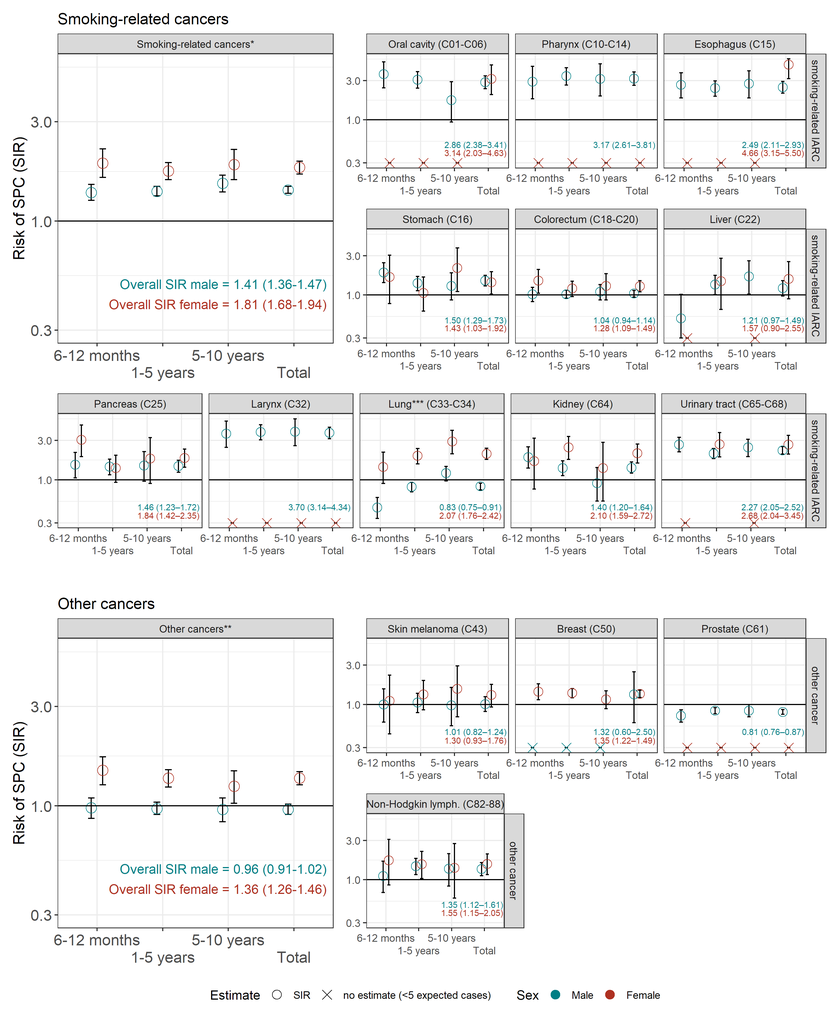

**Figure 1 Incidence of SPC in smoking-related and other cancer sites (n=135,589).** Showing site-specific SIRs stratified by sex on the log-transformed y-axis (for males in green and for females in red) and stratified by follow-up time on the x-axis.

Notes: SIR is only calculated for strata with at least 5 expected cases. Numeric SIR values are given for total follow-up time (6 months to 10+ years). Showing all sites with at least 70 observed or expected cases for males or 30 observed or expected cases for females for total follow-up time. * Total for “Smoking-related cancers” includes all SPC with locations C01-C06, C10-C14 C15-16, C18-20, C22, C25, C30, C31, C32, C33-34, C53, C56, C64, C65-68, C92. ** Total for “Other cancers” includes all other locations. *** The registration of a second primary lung cancer followed the IARC international rules for multiple primary cancers. SIR for lung cancer may be underestimated due to the histology-dependent registration of SPC with the same location as the first cancer.

## Table 2 Relative incidence of SPC stratified by follow-up time

Number of observed and expected SPC in main analysis (n=135,589) and standardized incidence ratios overall, by sex, by index lung cancer diagnosis and for grouped smoking-related and grouped other cancers, stratified by follow-up time.

| All sites combined | Total O | Total E | Total SIR | Total 95% CI | Total PYAR | Total N | 6-12 months SIR | 6-12 months 95% CI | 1-5 years SIR | 1-5 years 95% CI | 5-10 years SIR | 5-10 years 95% CI | 10+ years SIR | 10+ years 95% CI |
| --- | --- | --- | --- | --- | --- | --- | --- | --- | --- | --- | --- | --- | --- | --- |
| Overall | 5,298 | 4,116 | 1.29 | 1.25–1.32 | 280,155 | 135589 | 1.29 | 1.22–1.37 | 1.28 | 1.23–1.32 | 1.32 | 1.24–1.41 | 1.20 | 0.97–1.47 |
| Female | 1,492 | 962 | 1.55 | 1.47–1.63 | 95,827 | 43144 | 1.66 | 1.48–1.85 | 1.52 | 1.42–1.62 | 1.51 | 1.33–1.70 | 1.77 | 1.22–2.49 |
| Male | 3,806 | 3,153 | 1.21 | 1.17–1.25 | 184,327 | 92445 | 1.19 | 1.11–1.28 | 1.20 | 1.15–1.25 | 1.26 | 1.17–1.36 | 1.02 | 0.78–1.32 |
| Age at LC diagnosis |  |  |  |  |  |  |  |  |  |  |  |  |  |  |
| 30 - 54 | 528 | 191 | 2.77 | 2.54–3.01 | 49,577 | 20820 | 2.92 | 2.37–3.54 | 2.67 | 2.37–3.00 | 2.81 | 2.33–3.36 | 3.48 | 2.06–5.49 |
| 55 - 59 | 534 | 292 | 1.83 | 1.68–1.99 | 36,067 | 16333 | 2.18 | 1.81–2.61 | 1.71 | 1.52–1.91 | 1.83 | 1.50–2.21 | 2.02 | 1.11–3.40 |
| 60 - 64 | 966 | 605 | 1.60 | 1.50–1.70 | 48,821 | 21999 | 1.37 | 1.16–1.60 | 1.63 | 1.50–1.77 | 1.71 | 1.49–1.95 | 1.59 | 1.04–2.33 |
| 65 - 69 | 1,262 | 955 | 1.32 | 1.25–1.40 | 55,471 | 25684 | 1.31 | 1.15–1.48 | 1.34 | 1.24–1.43 | 1.30 | 1.15–1.48 | 1.18 | 0.74–1.78 |
| 70 - 74 | 1,008 | 983 | 1.03 | 0.96–1.09 | 46,389 | 23995 | 1.05 | 0.92–1.20 | 1.01 | 0.93–1.10 | 1.08 | 0.93–1.25 | 0.67 | 0.34–1.21 |
| 75 - 79 | 665 | 705 | 0.94 | 0.87–1.02 | 29,015 | 16374 | 1.07 | 0.92–1.24 | 0.95 | 0.86–1.05 | 0.78 | 0.63–0.97 | 0.30 | 0.06–0.87 |
| 80 - 84 | 260 | 306 | 0.85 | 0.75–0.96 | 11,799 | 7860 | 0.97 | 0.77–1.21 | 0.90 | 0.77–1.05 | 0.44 | 0.26–0.71 | 0.00 | 0.00–0.91 |
| 85+ | 75 | 80 | 0.93 | 0.74–1.17 | 3,017 | 2524 | 1.20 | 0.81–1.72 | 0.88 | 0.63–1.20 | 0.49 | 0.13–1.25 | 0.00 | 0.00–6.67 |
| Year of LC diagnosis |  |  |  |  |  |  |  |  |  |  |  |  |  |  |
| 2002 - 2005 | 2,245 | 1,679 | 1.34 | 1.28–1.39 | 115,984 | 42167 | 1.39 | 1.25–1.54 | 1.33 | 1.26–1.41 | 1.33 | 1.23–1.44 | 1.20 | 0.97–1.47 |
| 2006 - 2009 | 1,942 | 1,559 | 1.25 | 1.19–1.30 | 103,795 | 46213 | 1.30 | 1.17–1.43 | 1.21 | 1.15–1.28 | 1.30 | 1.17–1.45 | NA | NA |
| 2010 - 2013 | 1,111 | 877 | 1.27 | 1.19–1.34 | 60,376 | 47209 | 1.20 | 1.08–1.33 | 1.30 | 1.21–1.40 | NA | NA | NA | NA |
| Regional cancer registry |  |  |  |  |  |  |  |  |  |  |  |  |  |  |
| DE2 Bavaria | 1,353 | 975 | 1.39 | 1.31–1.46 | 71,827 | 33357 | 1.43 | 1.27–1.61 | 1.39 | 1.30–1.49 | 1.28 | 1.11–1.46 | 1.92 | 1.30–2.75 |
| DE4 Brandenburg | 304 | 288 | 1.06 | 0.94–1.18 | 19,329 | 9740 | 0.69 | 0.50–0.93 | 1.04 | 0.90–1.21 | 1.55 | 1.21–1.94 | 1.61 | 0.65–3.32 |
| DE5 Bremen | 135 | 112 | 1.20 | 1.01–1.42 | 7,427 | 3214 | 1.08 | 0.68–1.61 | 1.23 | 0.98–1.53 | 1.21 | 0.81–1.74 | 1.46 | 0.40–3.73 |
| DE6 Hamburg | 304 | 208 | 1.46 | 1.30–1.64 | 14,070 | 6926 | 1.75 | 1.38–2.18 | 1.38 | 1.18–1.61 | 1.37 | 1.01–1.81 | 1.71 | 0.63–3.71 |
| DE8 Mecklenburg-Western Pomerania | 223 | 191 | 1.17 | 1.02–1.33 | 12,362 | 6536 | 0.85 | 0.60–1.18 | 1.14 | 0.96–1.36 | 1.74 | 1.31–2.27 | 0.65 | 0.08–2.35 |
| DE9 Lower Saxony | 1,227 | 875 | 1.40 | 1.33–1.48 | 57,884 | 28735 | 1.59 | 1.42–1.78 | 1.36 | 1.26–1.47 | 1.41 | 1.23–1.61 | 0.60 | 0.32–1.03 |
| DEA3 Muenster | 400 | 305 | 1.31 | 1.19–1.45 | 20,048 | 10001 | 1.17 | 0.92–1.46 | 1.35 | 1.18–1.53 | 1.42 | 1.12–1.78 | 0.60 | 0.12–1.75 |
| DEC Saarland | 120 | 156 | 0.77 | 0.64–0.92 | 10,460 | 4741 | 0.67 | 0.41–1.03 | 0.85 | 0.67–1.07 | 0.71 | 0.45–1.05 | 0.00 | 0.00–1.14 |
| DED Saxony | 466 | 429 | 1.09 | 0.99–1.19 | 27,578 | 13561 | 1.09 | 0.89–1.33 | 1.05 | 0.93–1.18 | 1.16 | 0.93–1.44 | 1.63 | 0.84–2.84 |
| DEF Schleswig-Holstein | 531 | 352 | 1.51 | 1.38–1.64 | 23,363 | 11405 | 1.61 | 1.34–1.93 | 1.50 | 1.34–1.68 | 1.39 | 1.12–1.71 | 1.61 | 0.83–2.81 |
| DEG Thuringia | 235 | 225 | 1.04 | 0.91–1.19 | 15,805 | 7373 | 0.87 | 0.62–1.19 | 1.05 | 0.88–1.24 | 1.21 | 0.90–1.58 | 1.18 | 0.38–2.75 |
| Histology of LC |  |  |  |  |  |  |  |  |  |  |  |  |  |  |
| Adenocarcinoma | 1,826 | 1,397 | 1.31 | 1.25–1.37 | 101,649 | 46899 | 1.40 | 1.26–1.54 | 1.28 | 1.20–1.35 | 1.28 | 1.14–1.43 | 1.64 | 1.18–2.23 |
| Carcinoid | 135 | 99 | 1.37 | 1.15–1.62 | 9,775 | 2046 | 1.83 | 1.12–2.82 | 1.32 | 1.05–1.65 | 1.43 | 1.01–1.97 | 0.00 | 0.00–1.30 |
| Other NSCLC | 553 | 462 | 1.20 | 1.10–1.30 | 32,560 | 15377 | 1.08 | 0.88–1.31 | 1.27 | 1.14–1.41 | 1.11 | 0.90–1.37 | 1.04 | 0.48–1.97 |
| Small-cell carcinoma | 532 | 428 | 1.24 | 1.14–1.35 | 32,404 | 24361 | 1.20 | 1.02–1.40 | 1.27 | 1.13–1.42 | 1.29 | 1.02–1.60 | 0.98 | 0.39–2.02 |
| Squamous cell carcinoma | 1,988 | 1,493 | 1.33 | 1.27–1.39 | 89,795 | 38812 | 1.30 | 1.17–1.43 | 1.31 | 1.23–1.39 | 1.47 | 1.33–1.61 | 1.11 | 0.77–1.56 |
| Unspecified lung | 264 | 238 | 1.11 | 0.98–1.25 | 13,972 | 8094 | 1.27 | 1.00–1.59 | 1.09 | 0.92–1.27 | 0.99 | 0.69–1.37 | 0.81 | 0.22–2.08 |
| Site of SPC |  |  |  |  |  |  |  |  |  |  |  |  |  |  |
| Smoking-related cancers - Total | 3,158 | 2,123 | 1.49 | 1.44–1.54 | 280,155 | 135589 | 1.47 | 1.36–1.59 | 1.46 | 1.39–1.53 | 1.59 | 1.47–1.72 | 1.57 | 1.21–2.00 |
| Other cancers - Total | 2,140 | 1,993 | 1.07 | 1.03–1.12 | 280,155 | 135589 | 1.11 | 1.01–1.21 | 1.08 | 1.02–1.14 | 1.04 | 0.94–1.15 | 0.80 | 0.54–1.15 |
| Smoking-related cancers - Male | 2,414 | 1,711 | 1.41 | 1.36–1.47 | 184,327 | 92445 | 1.37 | 1.26–1.50 | 1.39 | 1.32–1.47 | 1.52 | 1.38–1.66 | 1.39 | 1.02–1.86 |
| Other cancers - Male | 1,392 | 1,443 | 0.96 | 0.91–1.02 | 184,327 | 92445 | 0.98 | 0.87–1.09 | 0.97 | 0.91–1.04 | 0.96 | 0.84–1.09 | 0.57 | 0.32–0.93 |
| Smoking-related cancers - Female | 744 | 412 | 1.81 | 1.68–1.94 | 95,827 | 43144 | 1.90 | 1.62–2.22 | 1.74 | 1.58–1.91 | 1.87 | 1.58–2.21 | 2.31 | 1.37–3.65 |
| Other cancers - Female | 748 | 550 | 1.36 | 1.26–1.46 | 95,827 | 43144 | 1.48 | 1.26–1.72 | 1.36 | 1.23–1.49 | 1.24 | 1.03–1.47 | 1.39 | 0.78–2.29 |

Notes: E number of cases expected according to age-, sex-, region- and period-specific reference rates for the general population; LC primary lung cancer; NSCLC non-small-cell lung carcinoma; O number of cases observed in the data; PYAR person-years at risk; SIR standardized incidence ratio; SPC second primary cancer

## Figure 2

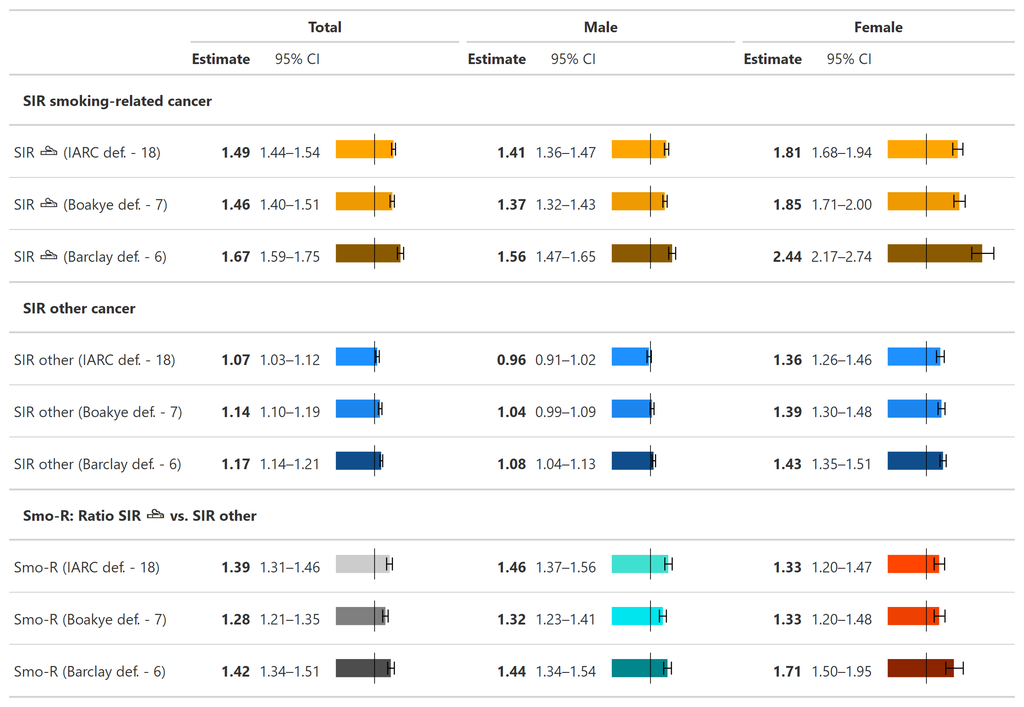

**Figure 2 Impact of smoking-relatedness definition on SIR estimates and risk for smoking-related vs. other second primary cancers.** Showing SIR estimate and respective 95% CI for smoking-related cancers (orange tones) according to three different definitions of smoking relatedness, then SIR for other cancers in the middle (blue tones) and the ratio of smoking-related vs. other cancer SIR at the bottom. The first column shows total estimates for the complete analysis dataset (n=135,589). The second column for males and the last column for females. For smoking-related cancers the Barclay definition results in higher SIR estimates than the IARC and Boakye definition, especially for females. Estimates for other cancers only show marginal differences. The ratio Smo-R is consistently above 1 for all definitions, indicating a 1.3 to 1.7-fold SIR for smoking-related cancers compared to other cancers.

Notes: Smoking-relatedness definition by *IARC* includes C00, C01-C06, C09-14, C15-16, C18-20, C22, C25, C30-34, C53, C56, C64-68, C92. *Boakye* definition is based on Boakye et al. 2019 and includes C00-14, C15-16, C18-20, C22, C25, C30-31, C33-34, C53, C64, C67. *Barclay* definition is based on Barclay et al. 2019 and includes C00-14, C15, C31, C33-34, C67. SIRs and Smo-R for Germany are calculated by the authors using the three different definitions of smoking-relatedness.

# References

1.

Seitz NN, Lochbühler K, Atzendorf J, Rauschert C, Pfeiffer-Gerschel T and, Kraus L. Trends in substance use and related disorders. *Deutsches Ärzteblatt International*. 2019;116(35-36):585--91. doi:10.3238/arztebl.2019.0585

2.

Mons U, Gredner T, Behrens G, Stock C, Brenner H. Cancers due to smoking and high alcohol consumption. *Deutsches Ärzteblatt International*. 2018;115(35-36):571-577. doi:10.3238/arztebl.2018.0571

3.

Walker MS, Vidrine DJ, Gritz ER, et al. Smoking Relapse during the First Year after Treatment for Early-Stage Non–Small-Cell Lung Cancer. *Cancer Epidemiology and Prevention Biomarkers*. 2006;15(12):2370-2377. doi:10.1158/1055-9965.EPI-06-0509

4.

Park ER, Japuntich SJ, Rigotti NA, et al. A snapshot of smokers following lung and colorectal cancer diagnosis. *Cancer*. 2012;118(12):3153-3164. doi:10.1002/cncr.26545

5.

Warren GW, Sobus S, Gritz ER. The biological and clinical effects of smoking by patients with cancer and strategies to implement evidence-based tobacco cessation support. *The Lancet Oncology*. 2014;15(12):e568-e580. doi:10.1016/S1470-2045(14)70266-9

6.

Barclay ME, Lyratzopoulos G, Walter FM, Jefferies S, Peake MD, Rintoul RC. Incidence of second and higher order smoking-related primary cancers following lung cancer: A population-based cohort study. *Thorax*. 2019;74(5):466-472. doi:10.1136/thoraxjnl-2018-212456

7.

Boakye EA, Buchanan P, Hinyard L, et al. Trends in the risk and burden of second primary malignancy among survivors of smoking-related cancers in the United States. *International Journal of Cancer*. 2019;145(1):143-153. doi:10.1002/ijc.32101

8.

Shiels MS, Gibson T, Sampson J, et al. Cigarette smoking prior to first cancer and risk of second smoking-associated cancers among survivors of bladder, kidney, head and neck, and stage i lung cancers. *Journal of Clinical Oncology*. 2014;32(35):3989-3995. doi:10.1200/JCO.2014.56.8220

9.

Baras N, Dahm S, Haberland J, et al. Subsequent malignancies among long-term survivors of Hodgkin lymphoma and non-Hodgkin lymphoma: a pooled analysis of German cancer registry data (1990–2012). *British Journal of Haematology*. 2017;177(2):226-242. doi:10.1111/bjh.14530

10.

Chen T, Brenner H, Fallah M, et al. Risk of second primary cancers in women diagnosed with endometrial cancer in German and Swedish cancer registries. *International Journal of Cancer*. 2017;141(11):2270-2280. doi:10.1002/ijc.30930

11.

Liu H, Hemminki K, Sundquist J, et al. Second primary cancers after cancer of unknown primary in sweden and germany: Efficacy of the modern work-up. *European Journal of Cancer Prevention*. 2013;22(3):210-214. doi:10.1097/CEJ.0b013e3283592c62

12.

Datensatz des ZfKD auf Basis der epidemiologischen Landeskrebsregisterdaten Epi2016_2, verfügbare Diagnosejahre bis 2014. Published online 2017. doi:10.18444/5.03.01.0005.0012.0002

13.

Arndt V, Holleczek B, Kajüter H, et al. Data from Population-based Cancer Registration for Secondary Data Analysis: Methodological Challenges and Perspectives. *Das Gesundheitswesen*. 2020;80(S 01):S62-S71. doi:10.1055/a-1009-6466

14.

GEKID. *Der Interaktive Krebs-Atlas Der GEKID. Methodische Hinweise*.; 2017:20.

15.

Wienecke A, Barnes B, Lampert T, Kraywinkel K. Changes in cancer incidence attributable to tobacco smoking in Germany, 19992008. *International Journal of Cancer*. 2014;134(3):682-691. doi:10.1002/ijc.28392

16.

Liu B, Quan X, Xu C, et al. Lung cancer in young adults aged 35 years or younger: A full-scale analysis and review. *Journal of Cancer*. 2019;10(15):3553-3559. doi:10.7150/jca.27490

17.

IARC. *International Rules for Multiple Primary Cancers (ICD-o Third Edition)*. International Agency for Research on Cancer; 2004. http://www.iacr.com.fr/images/doc/MPrules_july2004.pdf

18.

Secretan B, Straif K, Baan R, et al. A review of human carcinogenspart e: Tobacco, areca nut, alcohol, coal smoke, and salted fish. *The Lancet Oncology*. 2009;10(11):1033-1034. doi:10.1016/S1470-2045(09)70326-2

19.

Breslow NE, Day NE. *Statistical Methods in Cancer Research Volume II: The Design and Analysis of Cohort Studies*. International Agency for Research on Cancer; 1987. http://publications.iarc.fr/Book-And-Report-Series/Iarc-Scientific-Publications/Statistical-Methods-In-Cancer-Research-Volume-II-The-Design-And-Analysis-Of-Cohort-Studies-1986

20.

Thakur MK, Ruterbusch JJ, Schwartz AG, Gadgeel SM, Beebe-Dimmer JL, Wozniak AJ. Risk of Second Lung Cancer in Patients with Previously Treated Lung Cancer: Analysis of Surveillance, Epidemiology, and End Results (SEER) Data. *Journal of Thoracic Oncology*. 2018;13(1):46-53. doi:10.1016/j.jtho.2017.09.1964

21.

R Core Team. *R: A Language and Environment for Statistical Computing*. R Foundation for Statistical Computing; 2020. https://www.R-project.org/

22.

Fairbanks M. *Tidytable: Tidy Interface to ’Data.table’*.; 2020. https://CRAN.R-project.org/package=tidytable

23.

Wickham H, Averick M, Bryan J, et al. Welcome to the tidyverse. *Journal of Open Source Software*. 2019;4(43):1686. doi:10.21105/joss.01686

24.

Wickham H. *Ggplot2: Elegant Graphics for Data Analysis*. Springer; 2016. https://ggplot2.tidyverse.org

25.

Iannone R, Cheng J, Schloerke B. *Gt: Easily Create Presentation-Ready Display Tables*.; 2020. https://CRAN.R-project.org/package=gt

26.

Eberl M. *msSPChelpR: Helper Functions for Second Primary Cancer Analyses*.; 2021. doi:10.5281/zenodo.5055870

27.

Eberl M. Code for Paper “Incidence of smoking-related second primary cancers after lung cancer in Germany: an analysis of nationwide cancer registry data” submitted to Journal of Thoracic Oncology - marianschmidt/pub_spc_lung_cancer_jto. *GitHub*. Published online 2021. https://github.com/marianschmidt/pub_spc_lung_cancer_jto

28.

Abdel-Rahman O, Cheung WY. Subsequent thoracic cancers among patients diagnosed with lung cancer: a SEER database analysis. *Current Medical Research and Opinion*. 2017;33(11):2009-2017. doi:10.1080/03007995.2017.1333953

29.

Khanal A, Lashari BH, Kruthiventi S, et al. The risk of second primary malignancy in patients with stage Ia non-small cell lung cancer: A U.S. Population-based study. *Acta Oncologica*. 2018;57(2):239-243. doi:10.1080/0284186X.2017.1390250

30.

Jégu J, Colonna M, Daubisse-Marliac L, et al. The effect of patient characteristics on second primary cancer risk in France. *BMC Cancer*. 2014;14(1):94. doi:10.1186/1471-2407-14-94

31.

Tabuchi T, Ito Y, Ioka A, Nakayama T, Miyashiro I, Tsukuma H. Tobacco smoking and the risk of subsequent primary cancer among cancer survivors: A retrospective cohort study. *Annals of Oncology*. 2013;24(10):2699-2704. doi:10.1093/annonc/mdt279

32.

Youlden DR, Baade PD. The relative risk of second primary cancers in Queensland, Australia: A retrospective cohort study. *BMC Cancer*. 2011;11(1):1-12. doi:10.1186/1471-2407-11-83

33.

IARC Working Group on the Evaluation of Carcinogenic Risks to Humans, ed. *IARC Monographs on the Evaluation of Carcinogenic Risks to Humans, Volume 100 E, Personal Habits and Indoor Combustions.* International Agency for Research on Cancer; 2012.

34.

Gandini S, Botteri E, Iodice S, et al. Tobacco smoking and cancer: A meta-analysis. *International Journal of Cancer*. 2008;122(1):155-164. doi:10.1002/ijc.23033

35.

Weir HK, Johnson CJ, Ward KC, Coleman MP. The effect of multiple primary rules on cancer incidence rates and trends. *Cancer Causes & Control*. 2016;27(3):377-390. doi:10.1007/s10552-016-0714-9

36.

Hansen MS, Licaj I, Braaten T, Langhammer A, Le Marchand L, Gram IT. Sex Differences in Risk of Smoking-Associated Lung Cancer: Results From a Cohort of 600,000 Norwegians. *American Journal of Epidemiology*. 2018;187(5):971-981. doi:10.1093/aje/kwx339

37.

Huxley RR, Woodward M. Cigarette smoking as a risk factor for coronary heart disease in women compared with men: A systematic review and meta-analysis of prospective cohort studies. *The Lancet*. 2011;378(9799):1297-1305. doi:10.1016/S0140-6736(11)60781-2

38.

Fidler-Benaoudia MM, Torre LA, Bray F, Ferlay J, Jemal A. Lung cancer incidence in young women vs. Young men: A systematic analysis in 40 countries. *International Journal of Cancer*. 2020;147(3):811-819. doi:10.1002/ijc.32809

39.

Osazuwa-Peters N, Adjei Boakye E, Chen BY, Tobo BB, Varvares MA. Association Between Head and Neck Squamous Cell Carcinoma Survival, Smoking at Diagnosis, and Marital Status. *JAMA Otolaryngology - Head & Neck Surgery*. 2018;144(1):43-50. doi:10.1001/jamaoto.2017.1880

# Footnotes

## List of abbreviations

CI: confidence interval

DCO: death certificate only

IARC: International Agency for Research on Cancer

PBCR: population-based cancer registry

SEER: Surveillance, Epidemiology, and End Results Program

SIR: standardized incidence ratio

Smo-R: ratio between the overall SIR for smoking-related sites and the SIR for other cancer sites

SPC: second primary cancers

ZfKD: German Centre for Cancer Registry Data

## CRediT authorship contribution statement

Marian Eberl: Conceptualization; Methodology; Software; Formal Analysis; Data Curation; Writing – original draft; Writing – review and editing; Visualization

Luana F Tanaka: Validation; Resources; Writing – Original Draft; Writing – review and editing

Klaus Kraywinkel: Methodology; Validation; Resources; Writing – review and editing; Supervision

Stefanie J Klug: Conceptualization; Validation; Writing – review and editing; Supervision

## Data availability statement

Due to legal restrictions, the individual level raw data used for this analysis is only available via request to the German Centre for Cancer Registry Data (ZfKD) that can provide a scientific use file. More information on the application process is provided on the ZfKD website (https://www.krebsdaten.de/Krebs/EN/Content/ScientificUseFile/scientificusefile_node.html).

The authors of this paper strongly support open science and have therefore published both the analysis code and the newly programmed software to review and download under a GPL-3 license. The respective references are provided in the manuscript.

Repository for analysis code: https://github.com/marianschmidt/pub_spc_lung_cancer_jto

Repository for software code: https://doi.org/10.5281/zenodo.5055870

## Funding

This research did not receive any specific grant from funding agencies in the public, commercial, or not-for-profit sectors.

## Conflict of interest

The authors declare no conflict of interest.

## Ethics approval and consent to participate

This study analyzed the scientific use file (SUF) of the German Centre for Cancer Registry Data (ZfKD). Data collection is mandated and regulated by the German Federal Law on Cancer Registration (BKRG) and secondary data analysis of the anonymous SUF – as used in this study – does not require ethics approval or consent by patients (§3 and §5 BKRG).

## Supplementary material

File: “Submission_SPC after LC in Ger_JTO_Supplement S1-S12.pdf”

Description: The Supplement contains all supplementary material in one PDF file. This includes 12 supplementary figures and tables consecutively numbered S1 to S12.